# Projekt_nr1

Kamil Kućma

8 01 2022

**Część 1**

ćw1.9 wymaga zastosowania pętli i instrukcji warunkowych, czyli podstawowych funkcji każdego języka programowania. Ciężko zabierać się za analizę danych w programie, w którym nie zna się najbardziej podstawowych funkcji, które trzeba poznać

```r
ksiazki <- sample(x = 0:4, size = 25, replace = TRUE) # losowanie liczby przeczytanych książek
paste("średnia:",mean(ksiazki)) # średnia przeczytanych książek
```

```
## [1] "średnia: 2.28"
```

```r
paste("nie czyta: ", sum(ksiazki == 0)) # ile osób nie przeczytało żadnej książki
```

```
## [1] "nie czyta:  5"
```

```r
ksiazki2 <- c()
i <- 1
for(x in ksiazki){  # w zależności od wartości przeczytanych książek, do nowego wektora zostaje dodawana analogicznie informacja czy ktoś czyta na podstawie przeczytanej liczby książek
  if (x == 0)
  {
    ksiazki2[i] <- "nie czyta"
  }
  else
  {
    ksiazki2[i] <- "czyta"
  }
  i <- i+1
}
miesiac<-sample(1:12, 1)
rok<-sample(1:2022, 1)
paste("miesiąc ",miesiac,", ", rok," rok", sep = "")
```

```
## [1] "miesiąc 4, 458 rok"
```

```r
if (miesiac%%2!=0 || miesiac == 8){ # instrukcje warunkowe sprawdzają kolejne warunki i ustalają liczbę dni miesiąca
  paste(31, "dni")
} else if(miesiac == 2){
    if((rok%%4 == 0 && rok%%100 != 0) || rok%%400 == 0){
      paste(29, "dni")
    }
    else{
      paste(28, "dni")
    }
} else{
  paste(30, "dni")
}
```

```
## [1] "30 dni"
```

ćw 1.11 wymaga użycia funkcji, czyli czegoś, co pozwala unikać przepisywania poraz kolejny tego samego kodu oszczędzając nam tym samym czas. Sama funkcja jest prosta i działa na podstawie jednej instrukcji warunkowej.

```r
a <- sample(1:15, 1) # losowanie boków trójkąta - argumentów funkcji
b <- sample(1:15, 1)
c <- sample(1:15, 1)
trojkat <- function(x, y, z){ # deklaracja funkcji i przypisanie jej wyniku do zmiennej
  if (x > y+z || y > x+z || z > x+y){  #instrukcja sprawdza czy trójkąt o takich bokach może istnieć i jeśli tak to liczy jego pole
    print("Nie można utworzyć trójkąta")
  }
  else{
    p <- (x+y+z)/2
    paste("Pole trójkąta o bokach", x, y, z, "to:", round(sqrt(p*(p-x)*(p-y)*(p-z)), 2), sep= " ")
  }
}
trojkat(a, b, c)  # wywoałania funkcji
```

```
## [1] "Pole trójkąta o bokach 9 12 3 to: 0"
```

ćw 2.8 (i kolejne) wymagają wyciągnięcia pewnych interesujących nas danych z dużego zbioru danych i przedstawienia ich w dany sposób. Tutaj wybieramy tylko po 3 kraje z niskim pkb(<5000) z 3 kontynentów, które mają spośród nich najwyższą spodziewaną długość życia.

```r
library(gapminder)
library(dplyr)
library(tidyr) # wczytuje zbiór danych i dostęp do funkcji
top3_biednych <- gapminder %>%
  filter(year == "1977", gdpPercap<5000, continent %in% c("Europe", "Africa", "Asia"))%>% # wybieramy dany rok, przedział pkb i konkretne kontynenty
    group_by(continent) %>%  # grupujemy wyniki kontynentami
      top_n(3, lifeExp) %>% # wybieramy 3 z najwyższym lifeExp
        arrange(continent, desc(lifeExp)) # sortujemy kontynentami, malejąco po spodziewanej długości życia
top3_biednych
```

```
## # A tibble: 9 x 6
## # Groups:   continent [3]
##   country                continent  year lifeExp      pop gdpPercap
##   <fct>                  <fct>     <int>   <dbl>    <int>     <dbl>
## 1 Reunion                Africa     1977    67.1   492095     4320.
## 2 Mauritius              Africa     1977    64.9   913025     3711.
## 3 Tunisia                Africa     1977    59.8  6005061     3121.
## 4 Korea, Dem. Rep.       Asia       1977    67.2 16325320     4106.
## 5 Sri Lanka              Asia       1977    65.9 14116836     1349.
## 6 Malaysia               Asia       1977    65.3 12845381     3828.
## 7 Bosnia and Herzegovina Europe     1977    69.9  4086000     3528.
## 8 Albania                Europe     1977    68.9  2509048     3533.
## 9 Turkey                 Europe     1977    59.5 42404033     4269.
```

ćw2.9 Do wybranych danych dodajemy kolejną wartość, którą przydzielamy za pomocą instrukcji warunkowej i historycznej wiedzy(z Wikipedii). Następnie wyznaczamy podstawowe statystki opisowe dla tych danych.

```r
europa1987 <- gapminder%>%
  filter(year == "1987", continent == "Europe") %>%
  mutate(system = ifelse(country %in% c("Romania", "Montenegro", "Poland", "Hungary","Czech Republic", "Slovak Republic", "Bulgaria"), "RWPG", ifelse(country %in% c("Germany", "France", "Belgium", "Netherlands", "Italy", "Denmark", "Ireland", "Greece", "Spain", "Portugal"), "EU", "inne")))  # jeśli dany kraj znajduje się (lub nie) w podanej grupie, to przypisujemy do nowej zmiennej konkretną wartość

europa1987v2<-europa1987%>%
  select(system, gdpPercap, lifeExp, pop)%>%
  group_by(as.factor(system))%>%
  summarize(mean(gdpPercap), mean(lifeExp), median(gdpPercap), median(lifeExp), sd(gdpPercap), sd(lifeExp), quantile(lifeExp, probs=(0.25)), quantile(lifeExp, probs=(0.75)), quantile(gdpPercap, probs=(0.25)), quantile(gdpPercap, probs=(0.75)))

europa1987v2
```

```
## # A tibble: 3 x 11
##   `as.factor(system)` `mean(gdpPercap)` `mean(lifeExp)` `median(gdpPercap)`
##   <fct>                           <dbl>           <dbl>               <dbl>
## 1 EU                             19600.            75.7              20637.
## 2 inne                           18488.            73.4              21141.
## 3 RWPG                           11441.            71.3              11733.
## # ... with 7 more variables: median(lifeExp) <dbl>, sd(gdpPercap) <dbl>,
## #   sd(lifeExp) <dbl>, quantile(lifeExp, probs = (0.25)) <dbl>,
## #   quantile(lifeExp, probs = (0.75)) <dbl>,
## #   quantile(gdpPercap, probs = (0.25)) <dbl>,
## #   quantile(gdpPercap, probs = (0.75)) <dbl>
```

Widać dość wyraźnie, szczególnie na podstawie pkb, różnicę między krajami uwczesnej UE a krajami RWPG, oczywiście na korzyść tych pierwszych, co potwierdza się w ujęciu historycznym

ćw2.10 Wymaga przedstawienia danych na wykresie. Zależność między oczekiwaną długością życia, a rokiem w 3 wybranych krajach jest ukazana za pomocą jednego wykresu liniowego

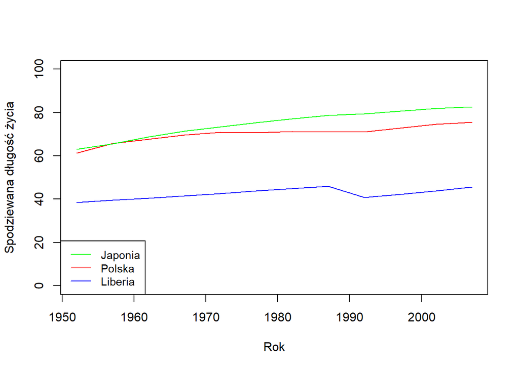

```r
kraje <- gapminder %>%
  filter(country %in% c("Poland", "Liberia", "Japan")) %>%
  group_by(country, year) %>%
  summarize(dl_zycia=lifeExp, .groups = "keep")
doKolumn <- spread(kraje, country, dl_zycia)

plot(doKolumn$year, doKolumn$Poland, type="l", col="red", ylim=c(0,100), xlab="Rok", ylab="Spodziewana długość życia")
lines(doKolumn$year, doKolumn$Liberia, type="l", col="blue", ylim=c(0,100), xlab="Rok", ylab="ex dl_zycia")
lines(doKolumn$year, doKolumn$Japan, type="l", col="green", ylim=c(0,100), xlab="Rok", ylab="ex dl_zycia")
legend("bottomleft", legend = c("Japonia", "Polska", "Liberia"), col = c("green", "red", "blue"), lty = 1, cex = 0.9)
```

Dzięki wykresowi łatwo zauważyć różnicę w spodziewanej długości życia między krajami “pierwszego i trzeciego świata”, dodatkowo widać zmianę wartości tej liczby w czasie, gdzie w Japonii rośnie ona dosyć regularnie, w Polsce rośnie w różnym tempie lub utrzymuje stałą wartość, a w Liberii przez większy czas rośnie, za wyjątkiem okresu kilku lat, gdzie ta wartość drastycznie malała (zapewne z powody wojny i chorób zakaźnych)

**Część 2**

wczytuję plik csv z zestawem danych

```r
budzet_org <- read.csv(file = "D:/R/budzety2005.csv", sep=",")
```

Zajmować się będę jedynie gospodarstwami domowymi, więc filtruję tylko “głowy domów”, aby na każde gospodarstwo przypadła tylko jedna osoba

```r
budzet <- budzet_org %>%
  filter(hoh==1) #%>%
  #group_by(hhno)%>%
  #summarize(n=n())   #każdy numer gospodarstwa domowego pojawia sie tylko raz
```

Na początek zbadajmy czy istnieje zależność między wielkością przychodów, a % jaki zostaje z niego zaoszczędzony, wraz z uwzględnieniem wielkości płaconych rachunków i rodzaju zamieszkiwanej miejscowości

```r
budzet_dochody <- budzet %>%
  filter(totexpGUS < totincGUS, mainincHH != "farmer") %>% #wykluczam rolników, którzy zazwyczaj mają nieregularne przychody i przypadki, gdzie nastąpiły większe wydatki (sytuacja gdzie wydatki>przychody na dłuższą metę nie może być normalna, więc zapewnie spowodowały ją niespodziewane większe wydatki)
  select(townsize, totincGUS, totexpGUS, bills) %>%
  mutate(zarobki = ifelse(totincGUS < 1200, "male", ifelse(totincGUS < 2300, "srednie", "duze")))%>% #summary(budzet$totincGUS), podział mniej więcej na równe części
  mutate(prc_oszczędzonego_przychodu = (totincGUS-totexpGUS) / totincGUS) %>%
  mutate(udział_rachunków_w_wydatkach = (bills / totexpGUS)) %>%
  group_by(zarobki, townsize) %>%
  summarize(srednia_oszczednosc = mean(prc_oszczędzonego_przychodu), sredni_udzial_rach = mean(udział_rachunków_w_wydatkach), .groups ="keep" ) %>%
  arrange(desc(srednia_oszczednosc))
budzet_dochody
```

```
## # A tibble: 18 x 4
## # Groups:   zarobki, townsize [18]
##    zarobki townsize          srednia_oszczednosc sredni_udzial_rach
##    <chr>   <chr>                           <dbl>              <dbl>
##  1 duze    villages                        0.298              0.131
##  2 duze    200,000 - 499,999               0.293              0.168
##  3 duze    500,000 and over                0.291              0.155
##  4 duze    20,000  - 99,999                0.277              0.169
##  5 duze    100,000 - 199,999               0.262              0.179
##  6 duze    town up to 19,999               0.257              0.160
##  7 srednie villages                        0.240              0.154
##  8 srednie town up to 19,999               0.237              0.217
##  9 srednie 200,000 - 499,999               0.230              0.242
## 10 srednie 20,000  - 99,999                0.217              0.229
## 11 srednie 500,000 and over                0.213              0.228
## 12 srednie 100,000 - 199,999               0.211              0.235
## 13 male    villages                        0.203              0.163
## 14 male    town up to 19,999               0.198              0.240
## 15 male    200,000 - 499,999               0.185              0.278
## 16 male    500,000 and over                0.173              0.274
## 17 male    20,000  - 99,999                0.170              0.279
## 18 male    100,000 - 199,999               0.169              0.261
```

Łatwo zauważyć zależność między tym, że im więcej rodziny zarabiały, tym większą część oszczędzały, co wydaje się normalne, choć nie zawsze pewne. Cieżej dostrzec zależność między wielkością miasta, w którym mieszakją rodziny, a zaoszczędzanym % przychodów, choć pod tym względem wyróżniają się gospodarstwa domowe na wsiach, które w każdej grupie zarobków, mają największy % oszczędzonych przychodów. Zapewne wynika to głównie z małego udziału płaconych rachunków(w 2005r na wsiach wodociągi, kanalizacja czy internet nie były tak powszechne a co za tym idzie nie powodowały wydatków) w całych wydatkach.

Zobaczmy teraz jak kształctują się wydatki i przychody z podziałem na miesiące

```r
budzet_miesiace <- budzet %>%
  filter(mainincHH != "farmer", totexpGUS < totincGUS) %>%
  group_by(month_hh) %>%
  summarize(średnie_wydatki = mean(totexpGUS), średnie_przychody = mean(totincGUS)) %>%
  arrange(desc(średnie_wydatki))
budzet_miesiace
```

```
## # A tibble: 12 x 3
##    month_hh średnie_wydatki średnie_przychody
##       <int>           <dbl>             <dbl>
##  1       12           1848.             2450.
##  2       10           1715.             2298.
##  3        9           1626.             2203.
##  4       11           1625.             2201.
##  5        5           1619.             2293.
##  6        7           1608.             2221.
##  7        3           1591.             2134.
##  8        8           1574.             2187.
##  9        6           1567.             2157.
## 10        4           1549.             2129.
## 11        1           1524.             2174.
## 12        2           1492.             2088.
```

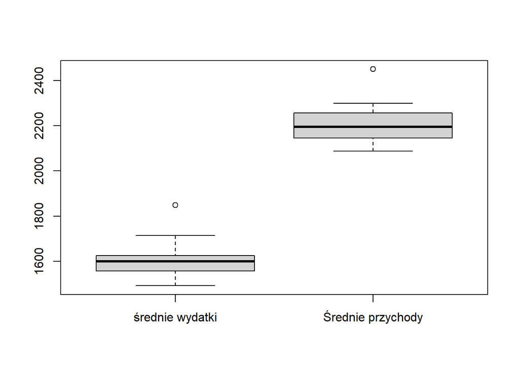

```r
boxplot(budzet_miesiace$średnie_wydatki, budzet_miesiace$średnie_przychody, names = c("średnie wydatki", "Średnie przychody"))
```

Grudzień najbardziej wyróżnia się ze wszystkich miesięcy. Jedyne odstające wartości zarówno w przychodach jak i wydatkach odnoszą się do niego. Można się domyślać, że z jednej strony to na święta i koniec roku pracownicy dostają premie i dodatki, a z drugiej wydają najwięcej na przygotowania do świąt czy prezenty. Ciekawe jest też to, że najmniejsze wydatki ponoszone są po świętach czyli w styczniu i lutym, tak jakby ludzie rekompensowali sobie poniesione straty w grudniu.

Skoro wczesniej odrzuciliśmy rolników, to teraz się na nich skupmy i poszukajmy zależności między liczbą rolników, wielkością posiadanego pola, czy województwami w których leżą.

```r
budzet_pole <- budzet %>%
  filter(farmsize > 0) %>%
  select(farmsize, wojregion) %>%
  group_by(wojregion) %>%
  summarize(liczba_gospodarstw_rolnych = n(), powierzchnia_pól = sum(farmsize), średnia_powierzhnia_gospodarstwa = mean(farmsize)) %>%
  arrange(desc(powierzchnia_pól))
budzet_pole
```

```
## # A tibble: 16 x 4
##    wojregion           liczba_gospodarstw~ powierzchnia_pól średnia_powierzhnia~
##    <chr>                             <int>            <dbl>                <dbl>
##  1 Lubelskie                           200            1104.                 5.52
##  2 Mazowieckie                         180             964.                 5.35
##  3 Lodzkie                             120             532.                 4.43
##  4 Kujawsko-pomorskie                   45             471.                10.5
##  5 Wielkopolskie                        80             393.                 4.91
##  6 Swietokrzyskie                       96             384.                 4.00
##  7 Dolnoslaskie                         42             306.                 7.28
##  8 Opolskie                             18             286.                15.9
##  9 Lubuskie                             17             256.                15.1
## 10 Warminsko-mazurskie                  16             241.                15.0
## 11 Pomorskie                            30             222.                 7.39
## 12 Podlaskie                            52             199.                 3.83
## 13 Malopolskie                          97             195.                 2.01
## 14 Podkarpackie                         98             193.                 1.97
## 15 Zachodniopomorskie                   19             149.                 7.86
## 16 Slaskie                              41             109.                 2.65
```

Sama suma obszarów pola z podziałem nie mówi wiele, gdyż w badaniu liczba badanych gospodarstw jest zależna od liczby mieszkańców województwa(table(budzet$wojregion) i dane gusowskie).

```r
table(budzet$wojregion)
```

```
##
##        Dolnoslaskie  Kujawsko-pomorskie             Lodzkie           Lubelskie
##                1103                 617                1050                 691
##            Lubuskie         Malopolskie         Mazowieckie            Opolskie
##                 314                1004                1769                 375
##        Podkarpackie           Podlaskie           Pomorskie             Slaskie
##                 601                 405                 696                1687
##      Swietokrzyskie Warminsko-mazurskie       Wielkopolskie  Zachodniopomorskie
##                 391                 477                 963                 602
```

Zobaczmy teraz jak wygląda liczba domowników w gospodarstwie domowym w zależności od rodzaju zabudowy i wielkości miejscowości.

```r
budzet_mieszkania <- budzet %>%
  group_by(buildtype, townsize) %>%
  summarize(Liczba_gosp = n(), średnia_liczba_domowników = mean(numpHH), średnia_wielkość = mean(flatsize), mkw_na_osobe = mean(flatsize) / mean(numpHH), .groups="keep") %>%
  arrange(desc(średnia_liczba_domowników)) %>%
  filter(Liczba_gosp > 10)
budzet_mieszkania
```

```
## # A tibble: 19 x 6
## # Groups:   buildtype, townsize [19]
##    buildtype townsize Liczba_gosp średnia_liczba_~ średnia_wielkość mkw_na_osobe
##    <chr>     <chr>          <int>            <dbl>            <dbl>        <dbl>
##  1 free sta~ villages        3158             2.67             83.2         31.1
##  2 free sta~ 200,000~          95             2.61             99.8         38.2
##  3 multi-fl~ villages         702             2.56             54.9         21.5
##  4 free sta~ town up~         390             2.54             92.5         36.5
##  5 terrace/~ villages         295             2.51             72.6         29.0
##  6 free sta~ 100,000~         156             2.5              98.6         39.5
##  7 free sta~ 20,000 ~         400             2.5              93.2         37.3
##  8 terrace/~ 500,000~          75             2.49             95.6         38.3
##  9 terrace/~ town up~          88             2.48             83.6         33.7
## 10 terrace/~ 20,000 ~         131             2.47             98.8         40.0
## 11 free sta~ 500,000~          98             2.44             92.7         38.0
## 12 terrace/~ 100,000~          28             2.39            113.          47.1
## 13 other     villages          24             2.38             46.3         19.5
## 14 multi-fl~ 20,000 ~        2054             2.30             49.0         21.3
## 15 terrace/~ 200,000~          67             2.28             97.5         42.7
## 16 multi-fl~ town up~         982             2.26             48.3         21.4
## 17 multi-fl~ 200,000~        1300             2.10             48.2         22.9
## 18 multi-fl~ 100,000~         867             2.10             47.4         22.6
## 19 multi-fl~ 500,000~        1815             1.99             46.2         23.2
```

Średnio więcej ludzi mieszka w jednym domu, niż w jednym mieszkaniu i wiecej na wsi niż w mieście. Wynika to oczywiście z większych powierzchni domów aniżeli mieszkań, które stanowią większość zabudowań na wsiach. Stosunek powierzchni do liczby domowników, nie aż tak wyraźnie, ale wciąż jest większy w domach. O ile mieszkania w miastach są średnio najmniej zaludnione, to o tyle mieszkania na wsiach wyglądają w tym aspekcie podobnie co domy w miastach.